# Exploring Red Wine Quality

Shane Kao

Wednesday, February 18, 2015

# Goal

Which chemical properties influence the quality of red wines?

# Data Overview

This tidy data set contains 1,599 red wines with 11 variables on the chemical properties of the wine. At least 3 wine experts rated the quality of each wine, providing a rating between 0 (very bad) and 10 (very excellent).

```r
setwd("C:/Users/shane/Downloads")
data=read.csv("wineQualityReds.csv",stringsAsFactors=FALSE)
str(data)
```

```
## 'data.frame':    1599 obs. of  13 variables:
##  $ X                   : int  1 2 3 4 5 6 7 8 9 10 ...
##  $ fixed.acidity       : num  7.4 7.8 7.8 11.2 7.4 7.4 7.9 7.3 7.8 7.5 ...
##  $ volatile.acidity    : num  0.7 0.88 0.76 0.28 0.7 0.66 0.6 0.65 0.58 0.5 ...
##  $ citric.acid         : num  0 0 0.04 0.56 0 0 0.06 0 0.02 0.36 ...
##  $ residual.sugar      : num  1.9 2.6 2.3 1.9 1.9 1.8 1.6 1.2 2 6.1 ...
##  $ chlorides           : num  0.076 0.098 0.092 0.075 0.076 0.075 0.069 0.065 0.073 0.071 ...
##  $ free.sulfur.dioxide : num  11 25 15 17 11 13 15 15 9 17 ...
##  $ total.sulfur.dioxide: num  34 67 54 60 34 40 59 21 18 102 ...
##  $ density             : num  0.998 0.997 0.997 0.998 0.998 ...
##  $ pH                  : num  3.51 3.2 3.26 3.16 3.51 3.51 3.3 3.39 3.36 3.35 ...
##  $ sulphates           : num  0.56 0.68 0.65 0.58 0.56 0.56 0.46 0.47 0.57 0.8 ...
##  $ alcohol             : num  9.4 9.8 9.8 9.8 9.4 9.4 9.4 10 9.5 10.5 ...
##  $ quality             : int  5 5 5 6 5 5 5 7 7 5 ...
```

```r
summary(data)
```

```
##        X          fixed.acidity   volatile.acidity  citric.acid
##  Min.   :   1.0   Min.   : 4.60   Min.   :0.1200   Min.   :0.000
##  1st Qu.: 400.5   1st Qu.: 7.10   1st Qu.:0.3900   1st Qu.:0.090
##  Median : 800.0   Median : 7.90   Median :0.5200   Median :0.260
##  Mean   : 800.0   Mean   : 8.32   Mean   :0.5278   Mean   :0.271
##  3rd Qu.:1199.5   3rd Qu.: 9.20   3rd Qu.:0.6400   3rd Qu.:0.420
##  Max.   :1599.0   Max.   :15.90   Max.   :1.5800   Max.   :1.000
##  residual.sugar     chlorides       free.sulfur.dioxide
##  Min.   : 0.900   Min.   :0.01200   Min.   : 1.00
##  1st Qu.: 1.900   1st Qu.:0.07000   1st Qu.: 7.00
##  Median : 2.200   Median :0.07900   Median :14.00
##  Mean   : 2.539   Mean   :0.08747   Mean   :15.87
##  3rd Qu.: 2.600   3rd Qu.:0.09000   3rd Qu.:21.00
##  Max.   :15.500   Max.   :0.61100   Max.   :72.00
##  total.sulfur.dioxide    density             pH          sulphates
##  Min.   :  6.00       Min.   :0.9901   Min.   :2.740   Min.   :0.3300
##  1st Qu.: 22.00       1st Qu.:0.9956   1st Qu.:3.210   1st Qu.:0.5500
##  Median : 38.00       Median :0.9968   Median :3.310   Median :0.6200
##  Mean   : 46.47       Mean   :0.9967   Mean   :3.311   Mean   :0.6581
##  3rd Qu.: 62.00       3rd Qu.:0.9978   3rd Qu.:3.400   3rd Qu.:0.7300
##  Max.   :289.00       Max.   :1.0037   Max.   :4.010   Max.   :2.0000
##     alcohol         quality
##  Min.   : 8.40   Min.   :3.000
##  1st Qu.: 9.50   1st Qu.:5.000
##  Median :10.20   Median :6.000
##  Mean   :10.42   Mean   :5.636
##  3rd Qu.:11.10   3rd Qu.:6.000
##  Max.   :14.90   Max.   :8.000
```

- The feature `X` is row index of data, it may provide no further information.
- The feature `quality` is an ordered, categorical, discrete variable.
- From the variable descriptions, {`fixed.acidity`,`volatile.acidity`,`citric.acid`} and {`free.sulfur.dioxide`,`total.sulfur.dioxide`} may strongly correlated.

# Univariate Plots Section

## Univariate Analysis

The following figures shows distributions for all features:

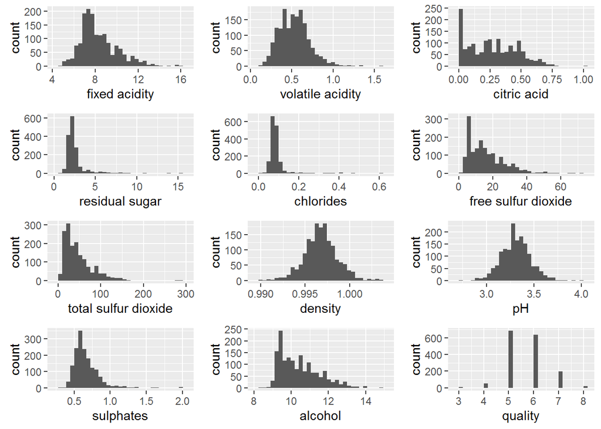

Now, we display density estimation for each features

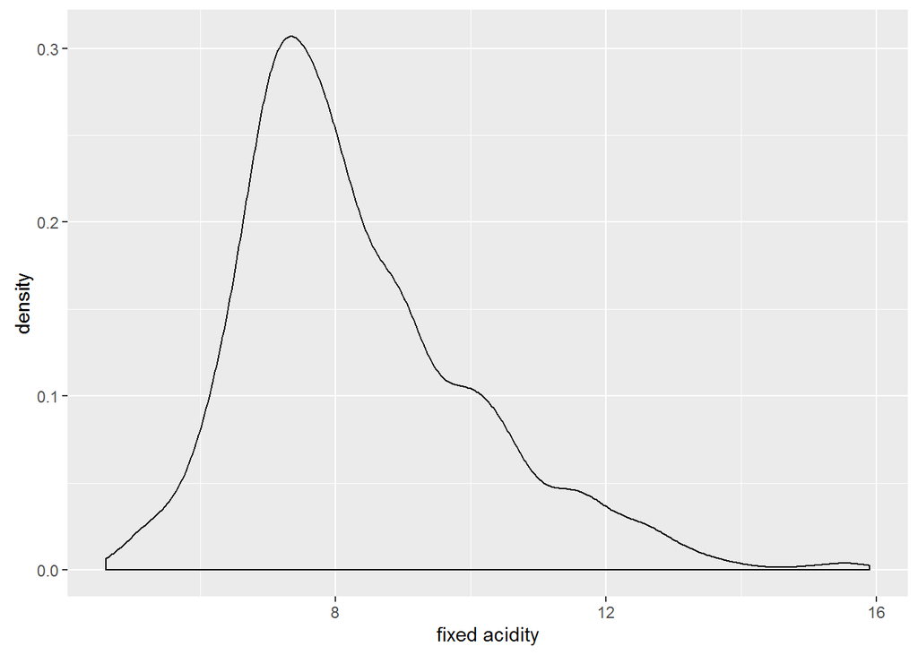

The sample average of `fixed.acidity` is about 8

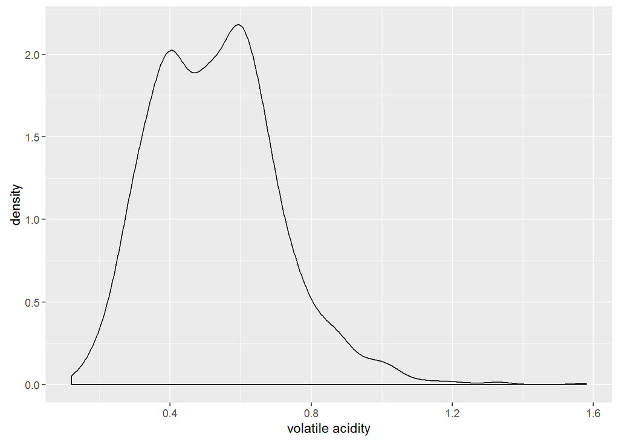

The distribution of `volatile.acidity` reveal bimodal

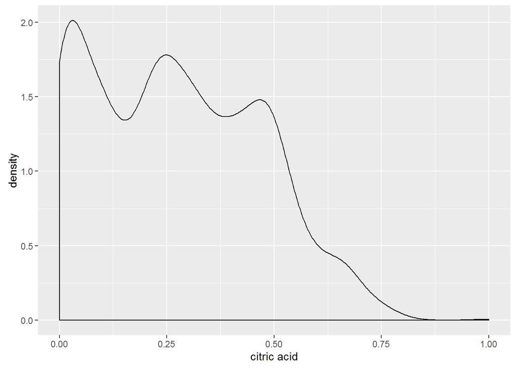

The distribution of `citric.acid` reveal trimodal

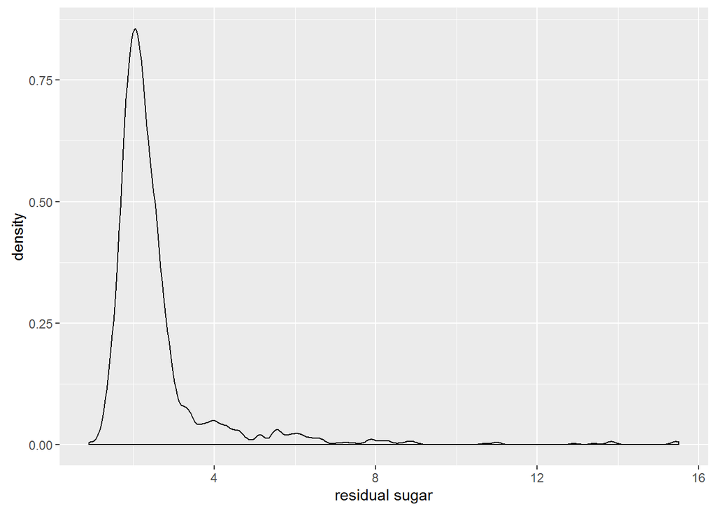

Most of the `residual.sugar` is smaller than 4

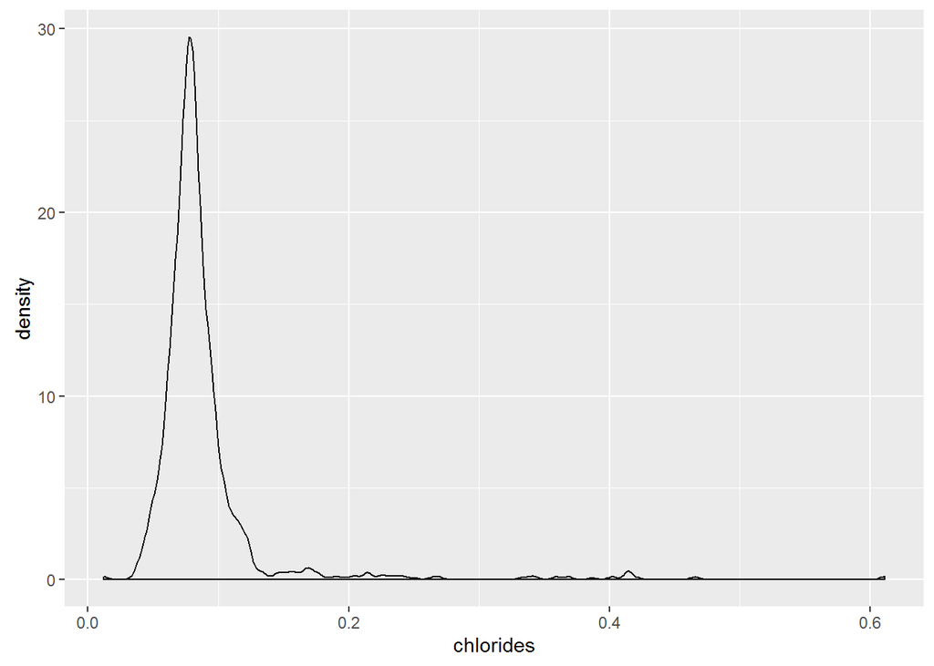

Most of the `chlorides` is smaller than 0.1

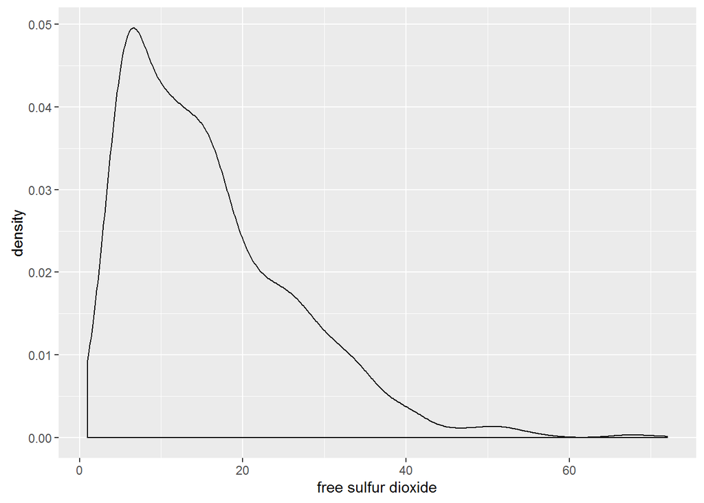

The mode of `free.sulfur.dioxide` is about 5

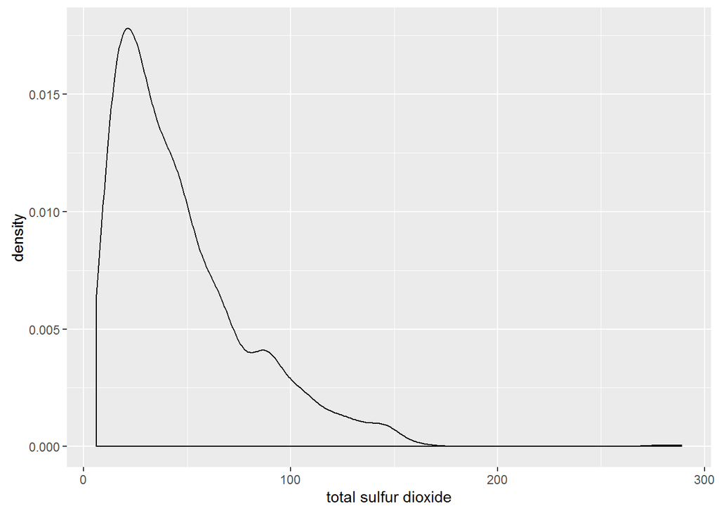

The shape of distribution for `total.sulfur.dioxide` and `free.sulfur.dioxide` are similar

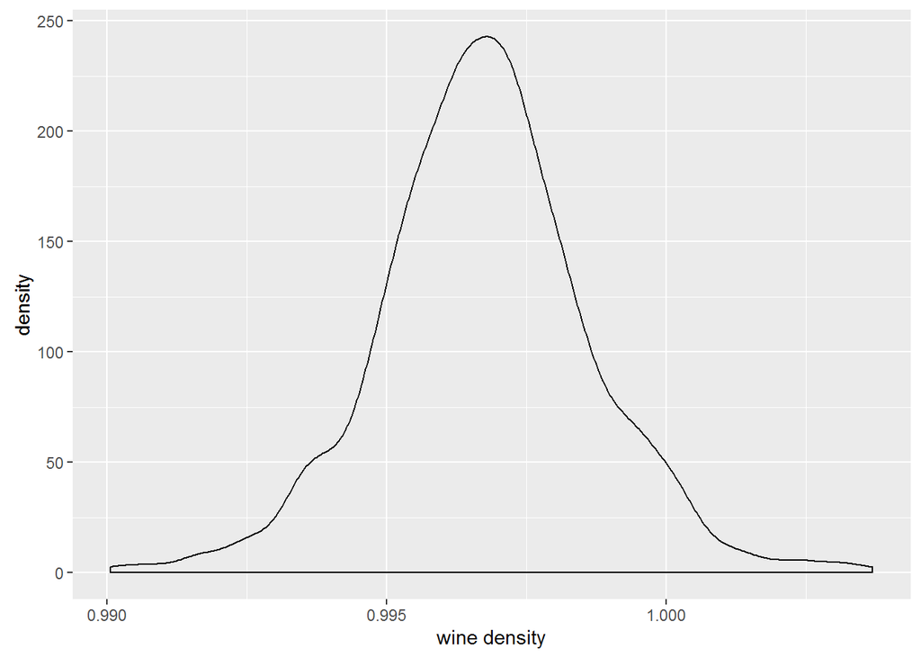

`density` appear to be normally-distributed.

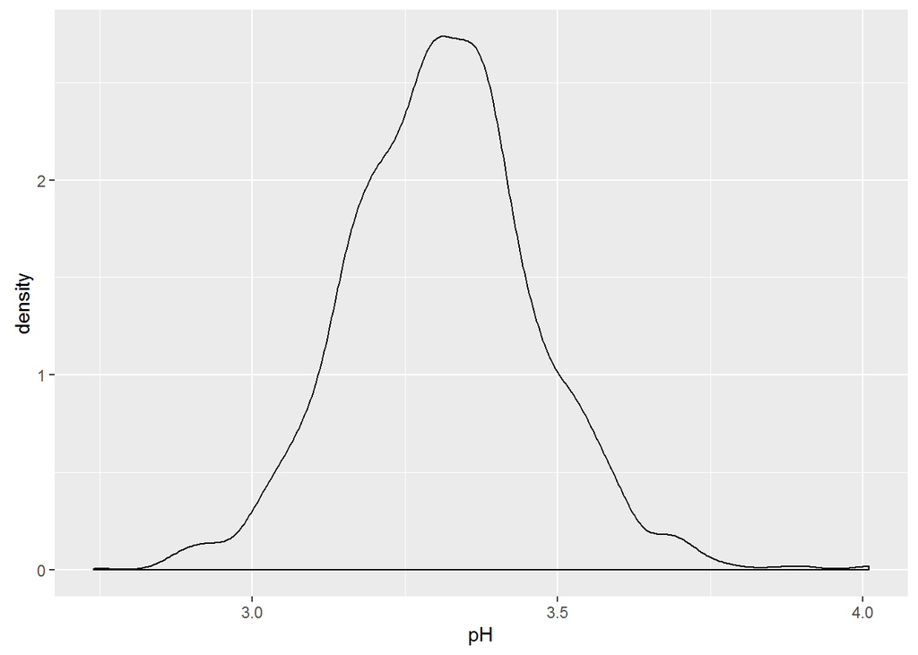

- `pH` appear to be normally-distributed.

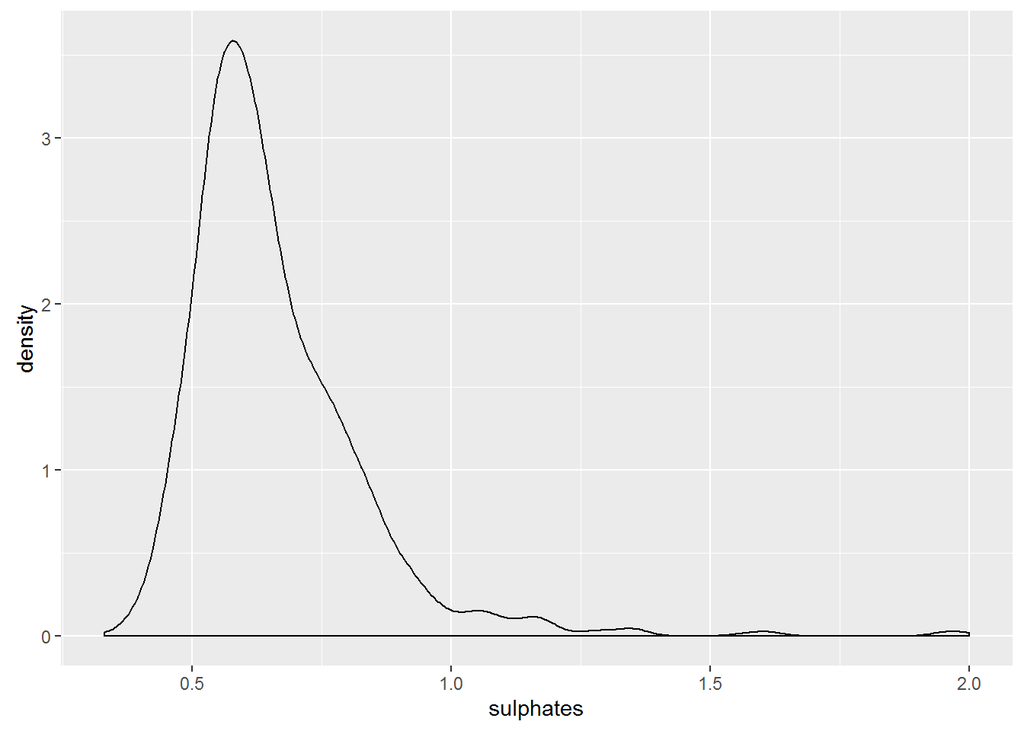

The mode of `sulphates` is about 0.6

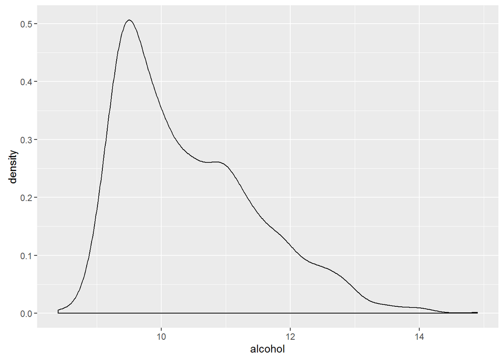

The mode of `alcohol` is about 9

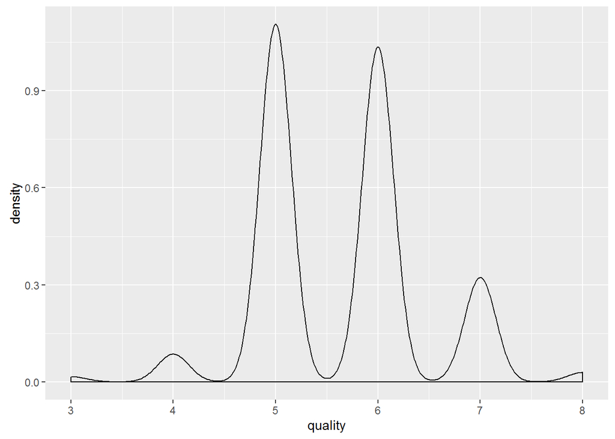

rating 5 and rating 6 has more points than other rating.

## Short questions

### Did you create any new variables from existing variables in the dataset?

- It is convenient to interpret the result by creating variable `rating` , classifying each wine as low, medium and high, assign `quality` 3 and 4 to low level, 5 and 6 to medium and 7 and 8 to high.

```r
data$rating<-rep("",dim(data)[1])
data$rating[which(data$quality%in%3:4)]<-"low"
data$rating[which(data$quality%in%5:6)]<-"medium"
data$rating[which(data$quality%in%7:8)]<-"high"
table(data$rating)
```

```
##
##   high    low medium
##    217     63   1319
```

- I create a combined variable, `acid`, taking average of `fixed.acidity`, `volatile.acidity` and `citric.acid` after standardization.

```r
data$acid<-((data$fixed.acidity-mean(data$fixed.acidity))/
                    sd(data$fixed.acidity)+
            (data$volatile.acidity-mean(data$volatile.acidity))/
                    sd(data$volatile.acidity)+
            (data$citric.acid-mean(data$citric.acid))/
                    sd(data$citric.acid))/3
```

- I create a combined variable, `dioxide`, taking average of `free.sulfur.dioxide` and `total.sulfur.dioxide` after standardization.

```r
data$dioxide<-((data$free.sulfur.dioxide-mean(data$free.sulfur.dioxide))/
                       sd(data$free.sulfur.dioxide)+
               (data$total.sulfur.dioxide-mean(data$total.sulfur.dioxide))/
                       sd(data$total.sulfur.dioxide))/2
```

### Of the features you investigated, were there any unusual distributions? Did you perform any operations on the data to tidy, adjust, or change the form of the data? If so, why did you do this?

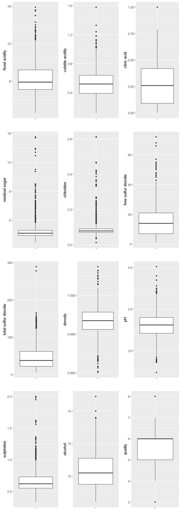

- `residual.sugar` and `chlorides` have extreme outliers.
- I don’t tidy or adjust any data.

# Bivariate Plots Section

## Bivariate Analysis

We use the following figure to check the correlation between different features

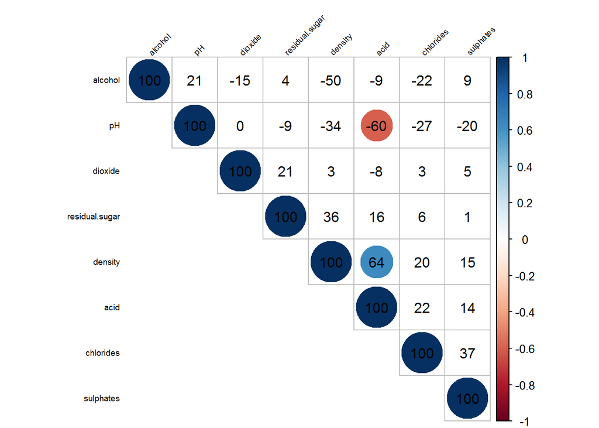

Most of features are un-correlated, but `acid` is correlated with `pH` and `density`. Note that there are only two points colored off the main diagonal (acid vs. density and acid vs ph) because corresponding correlation coefficient is regarded as significant.

The following boxplot shows how the features affect `rating`:

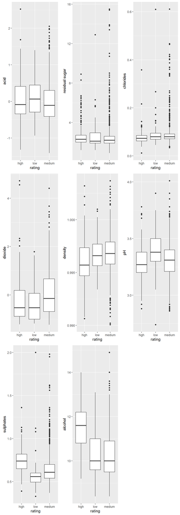

- Higher `alcohol`, higher `rating`.
- Higher `sulphates`, higher `rating`.
- Lower `pH`, higher `rating`.
- Lower `density`, higher `rating`.

We use `quality` to support above result

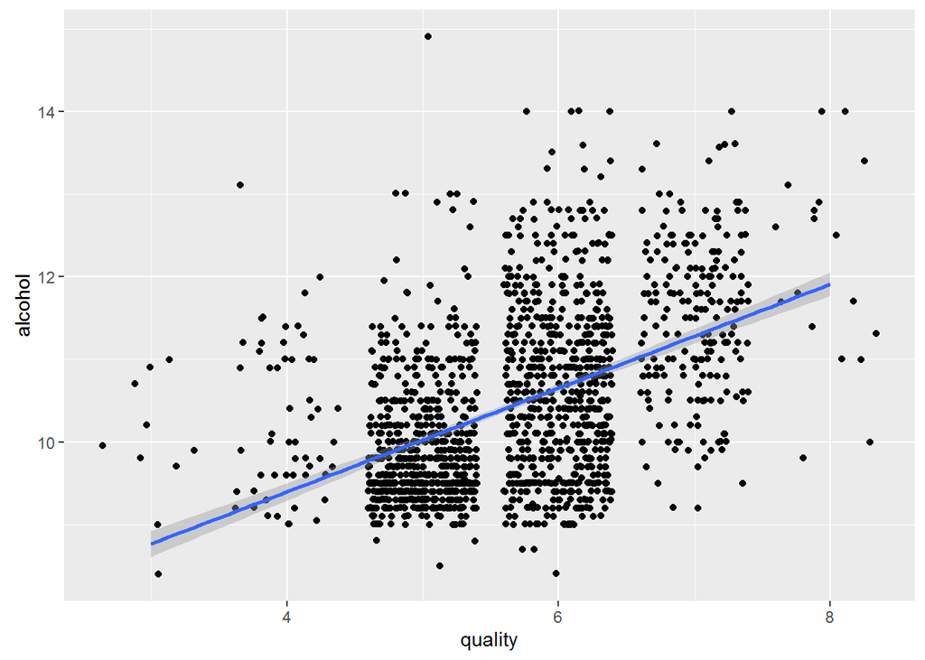

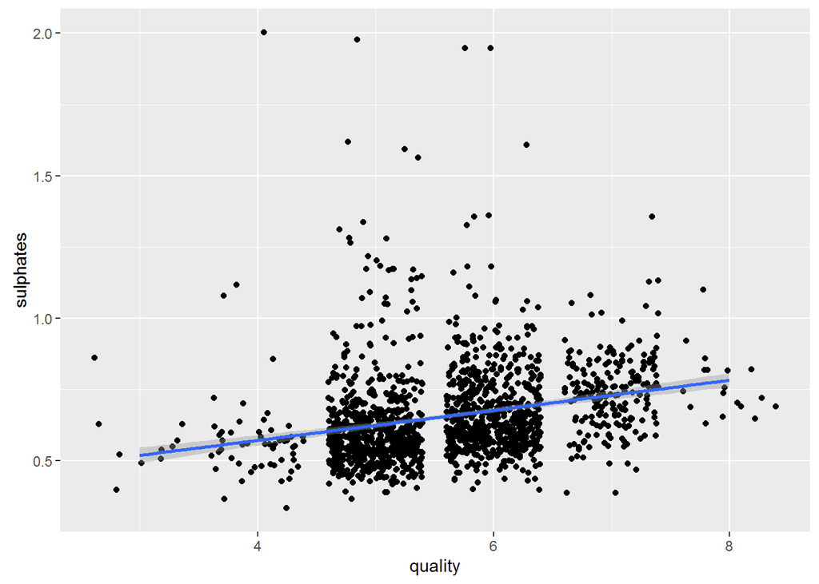

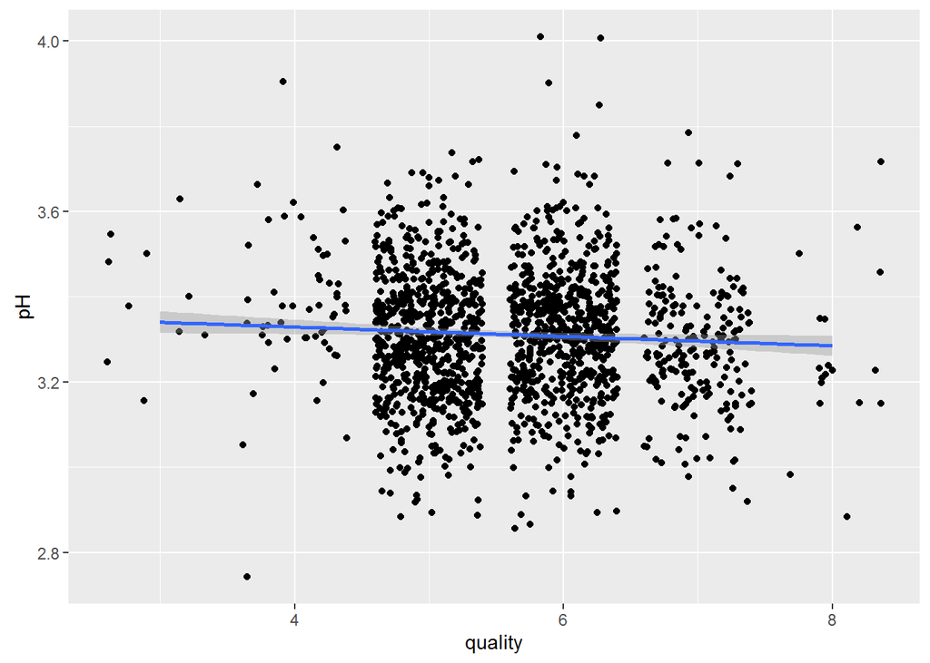

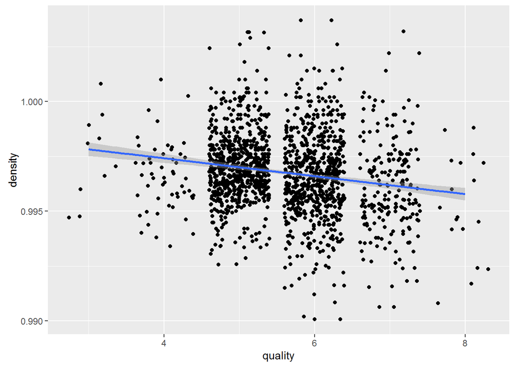

After using `quality`, we can see `alcohol` affect `quality` strongest.

- Higher `alcohol`, higher `rating`.
- Higher `sulphates`, higher `rating`.
- Lower `pH`, higher `rating`.
- Lower `density`, higher `rating`.

In Univariate Plots Section, we conclude that `density` and `pH` appear to be normally-distributed. Now we use the following plots to support the result

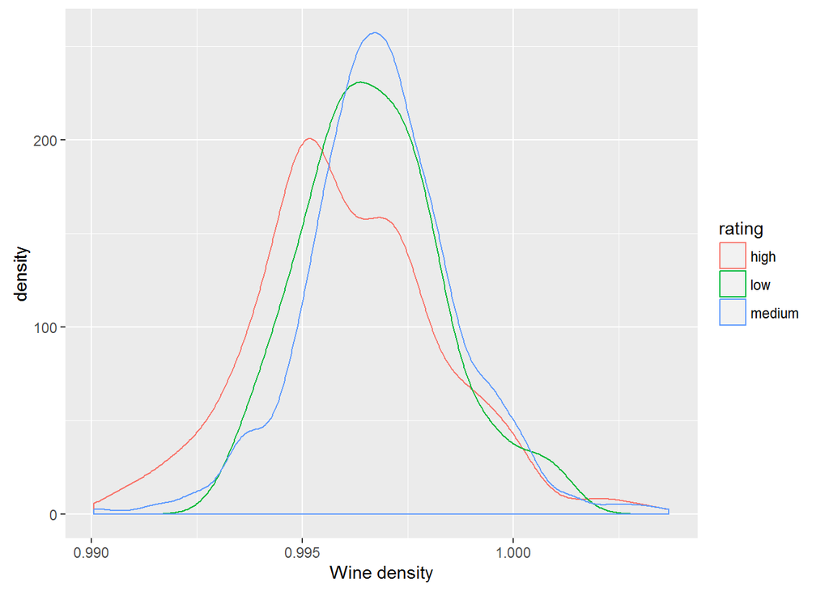

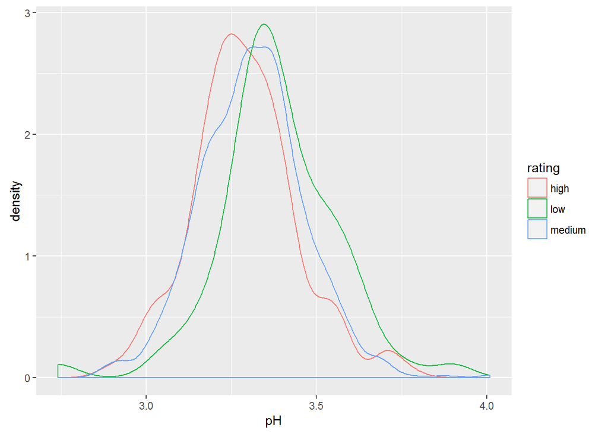

It seems like wine with medium level appear to normally-distributed. The result is not suprised because medium level have larger sample size.

## Short questions

### Talk about some of the relationships you observed in this part of the investigation. How did the feature(s) of interest vary with other features in the dataset?

We find out `alcohol`, `sulphates`, `density` and `pH` affect `rating` or `quality`.

### What was the strongest relationship you found?

Higher `alcohol`, higher `rating`.

# Multivariate Plots Section

## Multivariate Analysis

I examined the scatter plot of all the pair of features containing `alcohol`, `sulphates`, `density` and `pH` between different `quality`.

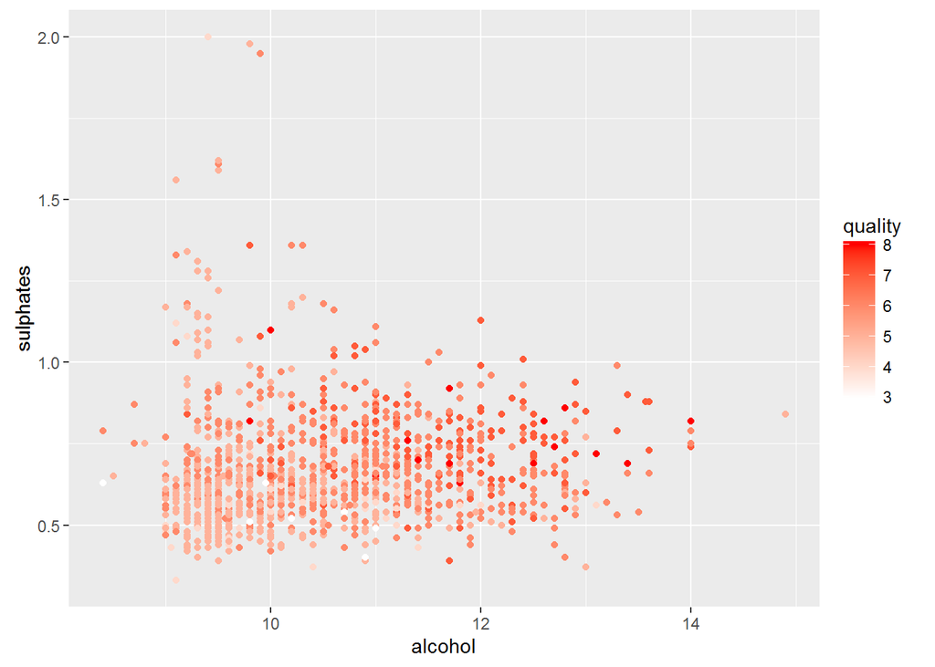

Lower `sulphates` and lower `alcohol`, lower `quality`.

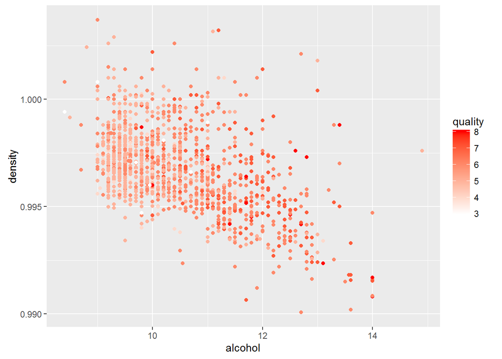

Higher `density` and lower `alcohol`, lower `quality`.

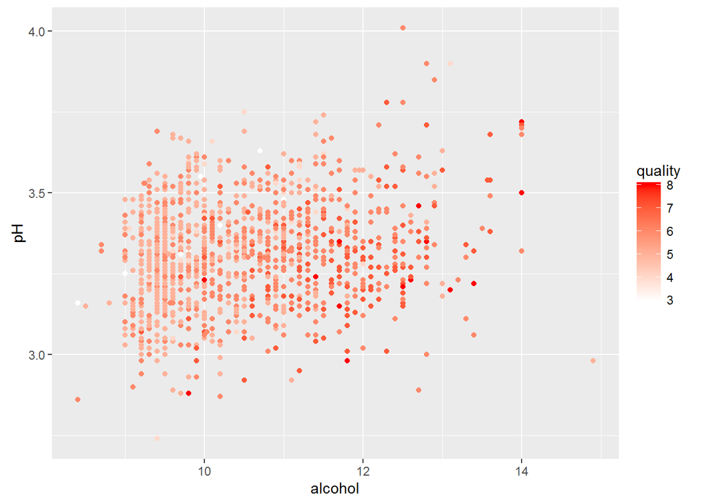

Higher `pH` and lower `alcohol`, lower `quality`.

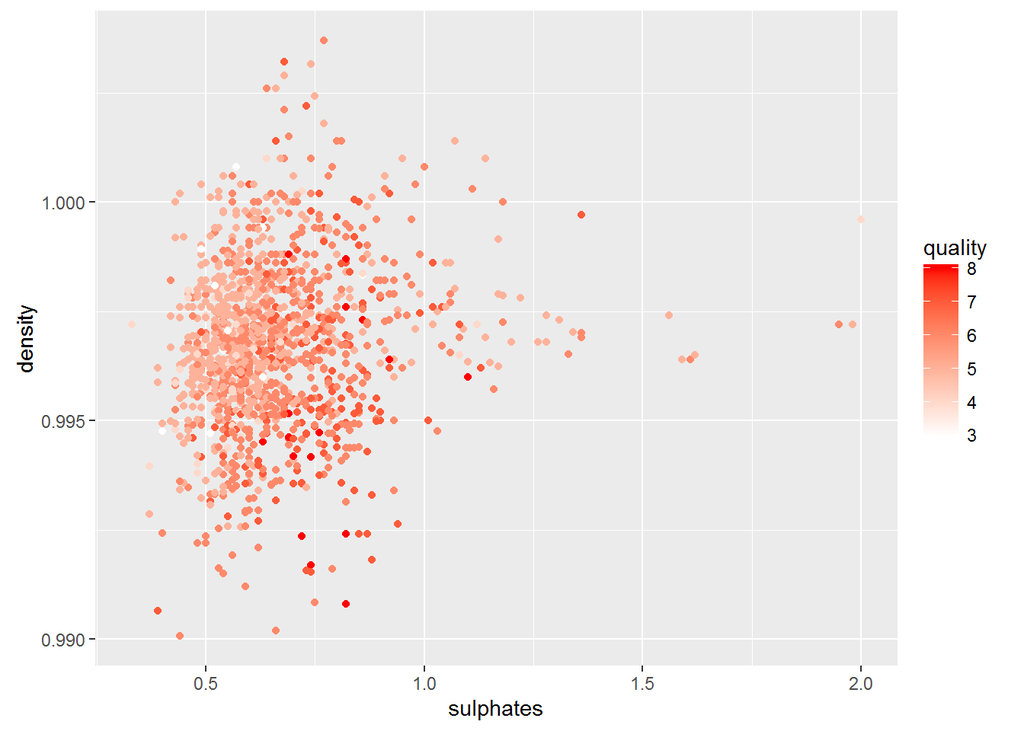

Lower `sulphates`, lower `quality`.

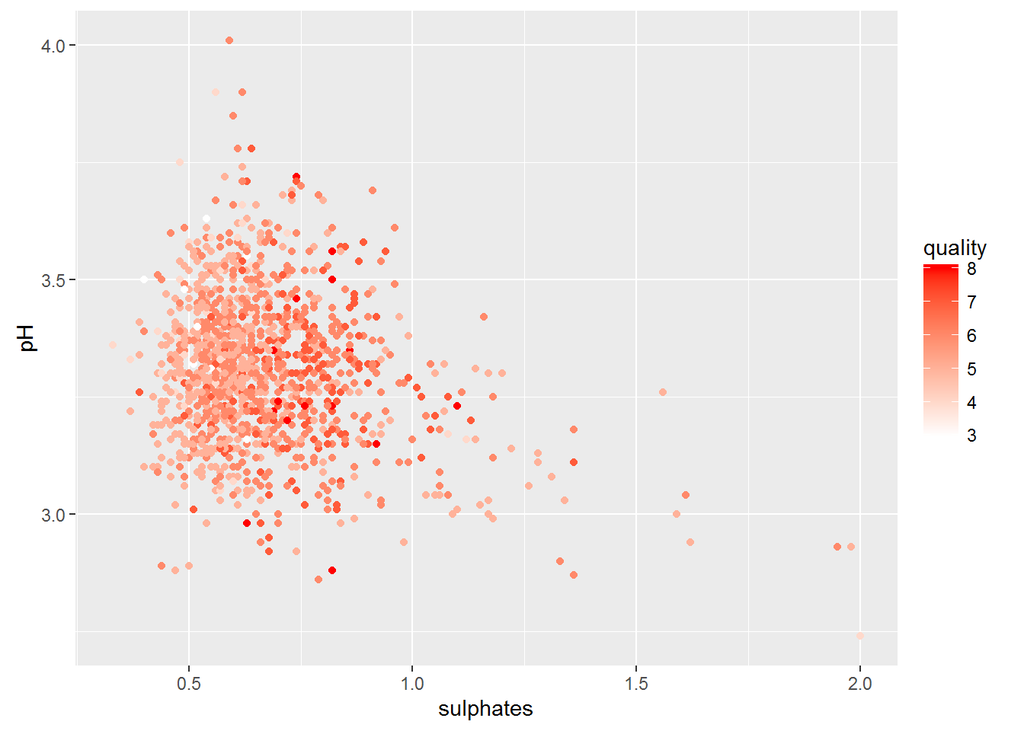

Lower `sulphates`, lower `quality`.

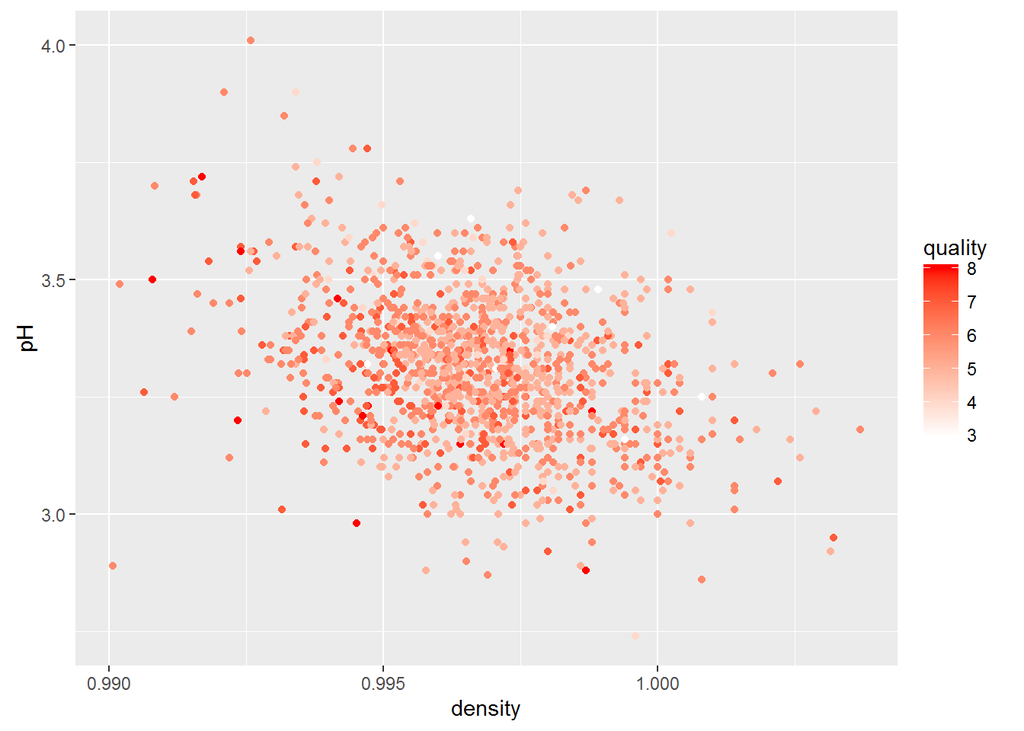

Higher `pH` and higher `density`, lower `quality`.

The above plots support the result in Bivariate Plots Section.

## Short questions

### Talk about some of the relationships you observed in this part of the investigation. Were there features that strengthened each other in terms of looking at your feature(s) of interest?

Higher `density` and lower `alcohol`, lower `quality`.

# Final Plots and Summary

## Plot One

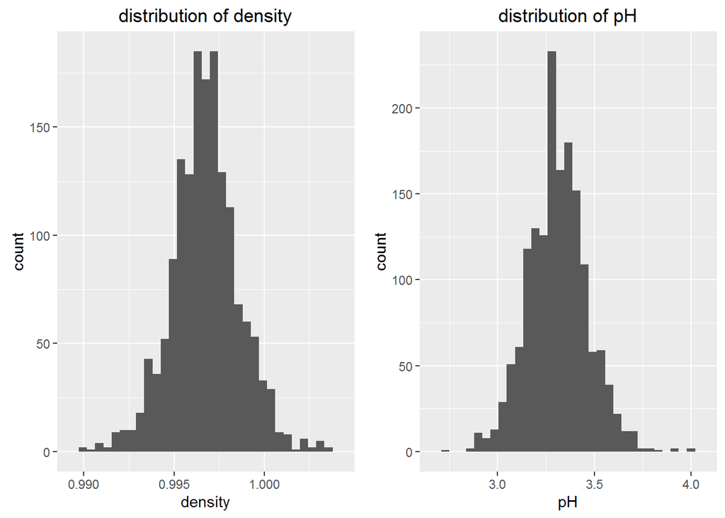

## Description One

`density` and `pH` appear to be normally-distributed. The numerical result as follows

```
##     density             pH
##  Min.   :0.9901   Min.   :2.740
##  1st Qu.:0.9956   1st Qu.:3.210
##  Median :0.9968   Median :3.310
##  Mean   :0.9967   Mean   :3.311
##  3rd Qu.:0.9978   3rd Qu.:3.400
##  Max.   :1.0037   Max.   :4.010
```

Statistical analyses often have dependent variables and independent variables and many parametric statistical methods require that the dependent variable is approximately normally distributed for each category of the independent variable. Although `density` and `pH` are not the dependent variable in the case, we can still use histogram to investigate the distribution or boxplot to show that is there exist outliers

### Plot Two

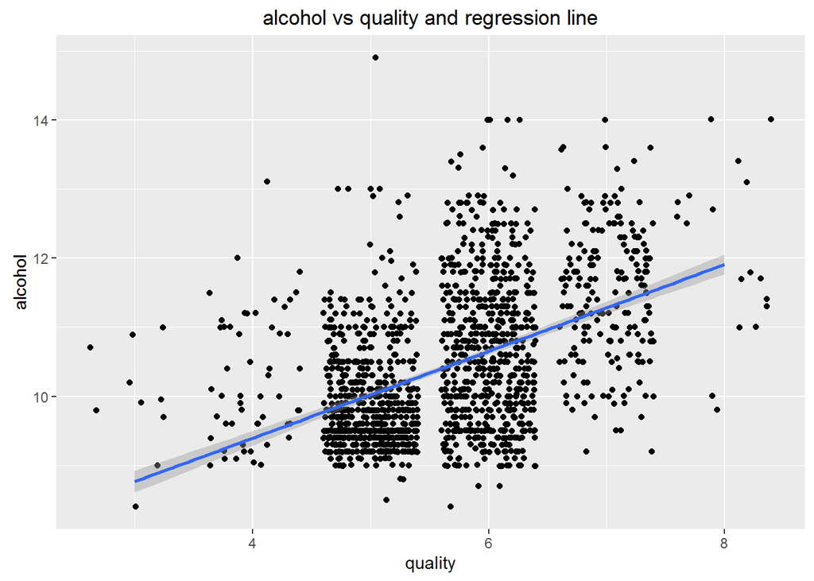

### Description Two

Higher `alcohol`, higher `quality`. The numerical result as follows

```r
model = lm(alcohol~quality, data)
summary(model)
```

```
##
## Call:
## lm(formula = alcohol ~ quality, data = data)
##
## Residuals:
##     Min      1Q  Median      3Q     Max
## -2.2517 -0.6233 -0.2233  0.5483  4.8767
##
## Coefficients:
##             Estimate Std. Error t value Pr(>|t|)
## (Intercept)  6.88160    0.16532   41.62   <2e-16 ***
## quality      0.62835    0.02904   21.64   <2e-16 ***
## ---
## Signif. codes:  0 '***' 0.001 '**' 0.01 '*' 0.05 '.' 0.1 ' ' 1
##
## Residual standard error: 0.9374 on 1597 degrees of freedom
## Multiple R-squared:  0.2267, Adjusted R-squared:  0.2263
## F-statistic: 468.3 on 1 and 1597 DF,  p-value: < 2.2e-16
```

The parameter of `quality` is larger than 0, and significant, so we can infer that `alcohol` is proportional to `quality`.

### Plot Three

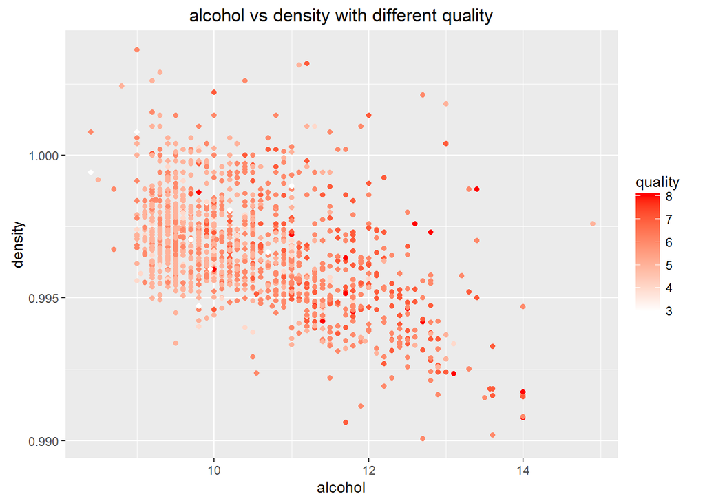

### Description Three

Higher `density` and lower `alcohol`, lower `quality`. The numerical result as follows

```r
model = lm(alcohol~quality+density, data)
summary(model)
```

```
##
## Call:
## lm(formula = alcohol ~ quality + density, data = data)
##
## Residuals:
##     Min      1Q  Median      3Q     Max
## -1.9271 -0.6025 -0.1143  0.5230  5.0193
##
## Coefficients:
##               Estimate Std. Error t value Pr(>|t|)
## (Intercept)  247.14603   11.08574   22.29   <2e-16 ***
## quality        0.53004    0.02593   20.44   <2e-16 ***
## density     -240.49274   11.09532  -21.68   <2e-16 ***
## ---
## Signif. codes:  0 '***' 0.001 '**' 0.01 '*' 0.05 '.' 0.1 ' ' 1
##
## Residual standard error: 0.8242 on 1596 degrees of freedom
## Multiple R-squared:  0.4026, Adjusted R-squared:  0.4018
## F-statistic: 537.8 on 2 and 1596 DF,  p-value: < 2.2e-16
```

Again, use linear model can verify the plots findings. R-squared is higher than prevoius one because we include `density` in the model, sometimes R-squared is just a metric for reference, if we include more variable in model, R-squared gets higher and higher, perform F-test, AIC or BIC, etc… to compare between different models and select the best one should be the further work.

# Reflection

- I enjoy in data visualization, it helps me in analyzing and reasoning about data and evidence.
- The numerical output in final plot descriptions supports the plots findings it provides further understanding of the data.
- I struggled in plot type in multivariate plots section, color or shape to represent the third variable takes me a long time, not use shape because it makes the point overlapping
- How to grouping `quality` also takes me a long time, no matter how I change the criteria, it is unbalance because wine experts give many 5 and 6 score of measure of wine quality
- My personal opinion about the data is that use the data of quality score {3,4} compare to {7,8} may show clearly patterns.
- Regression analysis is a statistical process for estimating the relationships among variables. Scatter plot in plot two and three give a rough view of the relationships among variables
- Through this exploratory data analysis, I think feature `alcohol` influence the quality of red wines
- Further study with machine learning could be done to predict the wine quality.